Skip to contents

# Tables for papers and the interactive application

Muhammad Yaseen

2026-11-05

Source: [`vignettes/DiallelAnalysisR_12_export_app.qmd`](https://github.com/myaseen208/DiallelAnalysisR/blob/HEAD/vignettes/DiallelAnalysisR_12_export_app.qmd)

## 1 Abstract

Results of every analysis can be written as tables for a paper, in Word, LaTeX, HTML, Markdown or CSV, with `da_export()`; `da_tables()` gives the same tables as data frames. `DiallelApp()` runs the analyses in a web browser without writing code. This vignette shows both.

## 2 The tables of an analysis

```r
fit <-
  Griffing(
      y          = Yield
    , Rep        = Rep
    , Cross1     = Cross1
    , Cross2     = Cross2
    , data       = GriffingData2
    , Method     = 2
    , Model      = 1
    , Reciprocal = c("combined", "split")[1]
    )
tb <-
  da_tables(
      x      = fit
    , digits = 3
    )
names(tb)
```

```
[1] "Analysis of variance"               "Components"
[3] "General combining ability effects"  "Specific combining ability effects"
[5] "Standard errors"
```

```r
tb[["Analysis of variance"]]
```

```
  Source  Df    Sum Sq Mean Sq F value Pr(>F)
1    gca   7  1850.893 264.413   9.470 <0.001
2    sca  28 12529.107 447.468  16.026 <0.001
3  Error 105  2931.770  27.922
```

Each analysis has its own set: Hayman’s analysis gives the analysis of variance, the $W_r$-$V_r$ table and the genetic parameters; the line $\times$ tester analysis the analysis of variance, the proportional contributions, the effects and the components; and so on.

## 3 Export to Word, LaTeX, HTML, Markdown or CSV

`da_export()` writes the tables, all or a chosen few, with a set number of decimal places. A LaTeX file uses the `booktabs` rules and can be included in a paper with `\input{}`:

```r
tex <- tempfile(fileext = ".tex")
da_export(
    x      = fit
  , file   = tex
  , format = c("docx", "latex", "html", "markdown", "csv")[2]
  , tables = "Analysis of variance"
  , digits = 2
  , title  = "Combining-ability analysis of variance"
  )
cat(readLines(con = tex), sep = "\n")
```

```
% Combining-ability analysis of variance
% tables written by DiallelAnalysisR::da_export(); needs \usepackage{booktabs}

\begin{table}[htbp]
\centering
\caption{Analysis of variance}
\begin{tabular}{lrrrrr}
\toprule
Source & Df & Sum Sq & Mean Sq & F value & Pr(>F) \\
\midrule
gca & 7 & 1850.89 & 264.41 & 9.47 & $<$0.001 \\
sca & 28 & 12529.11 & 447.47 & 16.03 & $<$0.001 \\
Error & 105 & 2931.77 & 27.92 &  &  \\
\bottomrule
\end{tabular}
\end{table}
```

A Word file (with the suggested packages officer and flextable) has one formatted table per result, each with its title, ready to paste into a manuscript:

```r
docx <- tempfile(fileext = ".docx")
da_export(
    x      = fit
  , file   = docx
  , format = c("docx", "latex", "html", "markdown", "csv")[1]
  , tables = NULL
  , digits = 3
  , title  = NULL
  )
file.exists(docx)
```

```
[1] TRUE
```

Markdown tables suit Quarto and R Markdown documents; CSV writes one file per table for a spreadsheet.

## 4 The interactive application

```r
DiallelApp(
    launch.browser = TRUE
  )
```

The application (packages shiny and bslib) has four tabs:

1. **Data**: an example data set of the package or a CSV file with one row per plot.
2. **Results**: the printed analysis and its tables. The sidebar sets the analysis (Griffing, Griffing over environments, heterosis, Hayman, Gardner and Eberhart, partial diallel, line $\times$ tester, North Carolina designs), the columns of the response, replicates and parents, and the options of the analysis.
3. **Plots**: every plot of the analysis.
4. **Export**: the tables in Word, LaTeX, HTML or Markdown, and the R code that repeats the analysis in a script, in the style of the examples of this package.

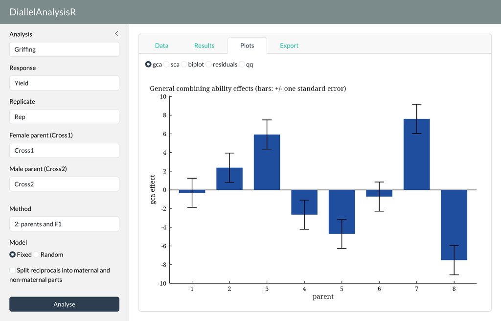

The application with Griffing’s Method 2 analysis of `GriffingData2`.

## 5 Summary

`da_tables()` and `da_export()` turn any result into tables for a report; `DiallelApp()` gives the same analyses and tables without code, and shows the code for later use.